# infinity_parameters_logistic

## Parameters Diverging to $\pm \infty$ in Logistic Regression

#### Suraj Rampure (suraj.rampure@berkeley.edu)

*Updated May 15, 2019*

Motivation: There have been several questions, both in OH and on Piazza, regarding the divergence of parameters in logistic regression when our data is linearly separable. This notebook is meant to provide some sort of intuition, but doesn't walk through any math rigorously.

For this notebook, suppose our model is $$P(Y = 1 \: \big| \:X = x) = \sigma(\beta_0 + \beta_1x) = \frac{1}{1 + e^{-(\beta_0 + \beta_1 x)}}$$

Also, for the purposes of this notebook, we'll only investigate the role of $\beta_1$, and not $\beta_0$.

```python
import numpy as np
import matplotlib.pyplot as plt
%matplotlib inline
```

```python
def sigmoid(t):
    return 1 / (1 + np.e**(-t))
```

### Positive Infinity

Let's visualize our toy dataset. Remember, in classification, $y$ represents the class label. For us, that means 0 or 1.

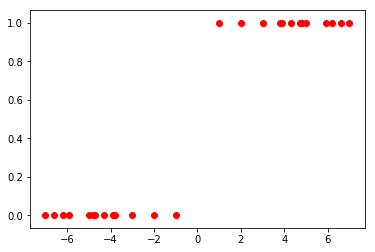

```python
xs = [-7, -6.6, -6.2, -5.9, -5, -4.8, -4.7, -4.3, -3.9, -3.8, -3, -2, -1]
xs += [-i for i in xs]
ys = [0 for _ in range(13)] + [1 for _ in range(13)]

plt.scatter(xs, ys, color = 'r');
```

Let's look at the sigmoid curve overlaid on these points with increasing values of $\beta$:

```python
beta_0 = 0 # We're only looking at the role of beta_1 here, so we've fixed beta_0
beta_1_choices = [1, 2, 5, 10, 100]
```

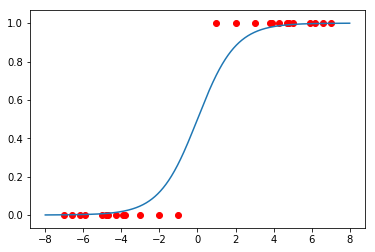

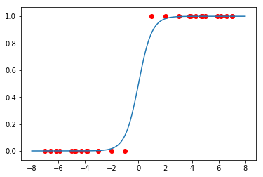

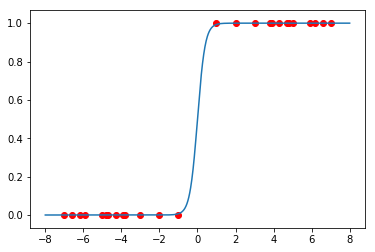

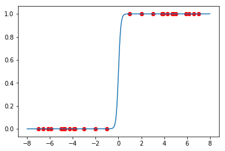

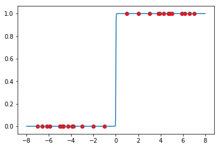

```python
x = np.linspace(-8, 8, 1000)
for beta_1 in beta_1_choices:
    y = sigmoid(beta_0 + beta_1 * x)
    plt.plot(x, y)
    plt.scatter(xs, ys, color = 'r')
    plt.show()
```

This can be rigorously justified by looking at the gradient descent update equation.

### Negative Infinity

However, let's now flip our points:

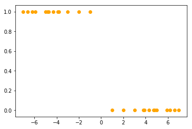

```python
ys_neg = [0 if yi == 1 else 1 for yi in ys]
plt.scatter(xs, ys_neg, color = 'orange');
```

And look at decreasing values of beta:

```python
beta_0 = 0
beta_1_choices = [-1, -2, -5, -10, -100]
```

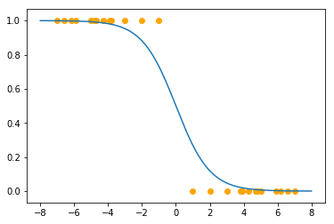

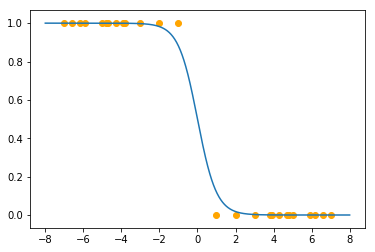

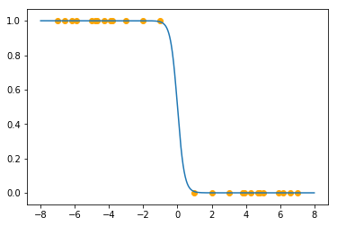

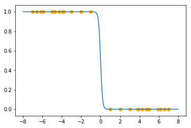

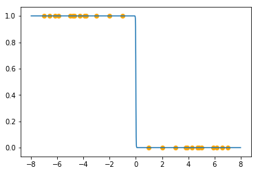

```python
x = np.linspace(-8, 8, 1000)
for beta_1 in beta_1_choices:
    y = sigmoid(beta_0 + beta_1 * x)
    plt.plot(x, y)
    plt.scatter(xs, ys_neg, color = 'orange')
    plt.show()
```

**Conclusion**:

Suppose we have a set of scalars $x$ along with class labels $y$, and our data is linearly separable. Furthermore, suppose our model is $P(Y = 1 \: \big| \: X = x) = \sigma(\beta_0 + \beta_1 x)$. If we can create the following classifier, for some constant $x_0$:

$$classify(x) = \begin{cases} 1 && x \geq x_0 \\ 0 && x < x_0 \end{cases}$$

Then, $\beta_1 \rightarrow \infty$ (or, in terms of past exam questions, "our parameters diverge to positive infinity"). Intuitively speaking, this is the case where all of the class 1 points are "to the right" of all of the class 0 points.

In the opposite case, where we can create the following classifier:

$$classify(x) = \begin{cases} 0 && x \geq x_0 \\ 1 && x < x_0 \end{cases}$$

Then, $\beta_1 \rightarrow - \infty$ (or, again, in terms of past exam questions, "our parameters diverge to negative infinity"). This is the case where all of the class 1 points are "to the left" of all of the class 0 points.

**Clarification**: Previously, this notebook stated that only $\beta_1$ would approach $\pm \infty$, and not $\beta_0$. This interpretation was not exactly correct, and so I removed any discussion of $\beta_0$ here. @1305 from Spring 2019's Piazza has a nice discussion of this idea (maybe in the future I'll add that information here...)